# hw2.R

JINWEN XU jxu587@wisc.edu

2023-09-29

1.**Describe the measure you chose and why you chose it:** The Cross-Correlation Function (CCF) is a widely used tool in time series analysis to measure the correlation between two time series. Here’s why we employ CCF and why we use $1 - \text{ccf.result}$ as a distance metric:

1.1. **Identifying Shifts**: - The CCF measures the correlation of two series at different lags. The peak value indicates the best alignment between the series.

1.2. **Formula**: For two time series $x_t$ and $y_t$, their cross-correlation at lag $h$ is defined as: For two time series $x_t$ and $y_t$, their cross-correlation at lag $h$ is defined as:
$$r_{xy}(h) = \frac{\sum_{t=1}^{T-h} (x_{t+h} - \bar{x})(y_t -
\bar{y})}{\sqrt{\sum_{t=1}^T (x_t - \bar{x})^2 \sum_{t=1}^T (y_t -
\bar{y})^2}}$$
where $\bar{x}$ and $\bar{y}$ are the means of $x$ and $y$ respectively.

1.3. **Normalization**: - The values of the CCF lie between -1 and 1. A value of 1 indicates perfect positive correlation, -1 indicates perfect negative correlation, and 0 indicates no correlation.

1.4. **Distance Measure**: - Adopting $1 - \text{ccf.result}$ serves to convert the correlation value from the CCF into a distance metric. The closer the CCF value is to 1, the smaller the distance, indicating greater similarity between the two series.

In essence, the CCF helps gauge the similarity between two time series, and through an appropriate transformation, this similarity can be quantified.

2.**Mention difficulties I had:**

1. **Correctly reading and standardizing data paths is a complex process**.
2. **Since there is a large amount of data, ensuring that the loop runs without errors is also a challenging task**.

3.**read csv and plot**

```r
data <- read.csv("hw2.csv")
head(data)
```

```
##    distance                  filename   i
## 1 0.5859109 spec-5328-55982-0218.fits 905
## 2 0.5897619 spec-1353-53083-0579.fits 519
## 3 0.5976339 spec-5301-55987-0190.fits  88
## 4 0.6056327 spec-2557-54178-0009.fits  94
## 5 0.6195660 spec-7089-56661-0076.fits  61
## 6 0.6232911 spec-2261-53612-0404.fits 222
```

```r
require("FITSio")
```

```
## file=spec-5328-55982-0218.fits
## path_to_file=data/spec-5328-55982-0218.fits
```

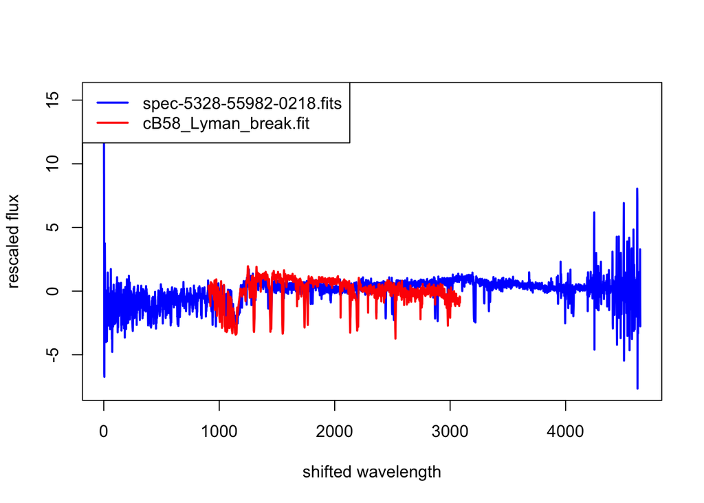

```
## file=spec-1353-53083-0579.fits
## path_to_file=data/spec-1353-53083-0579.fits
```

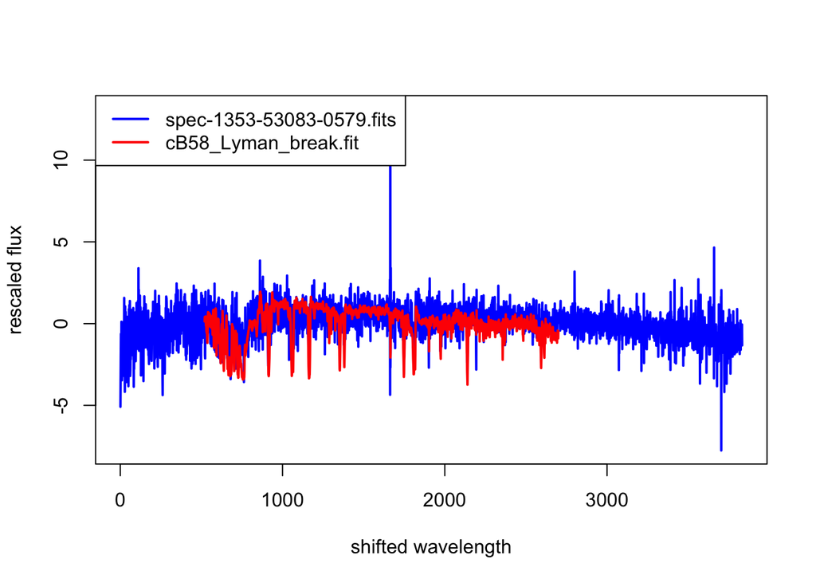

```
## file=spec-5301-55987-0190.fits
## path_to_file=data/spec-5301-55987-0190.fits
```

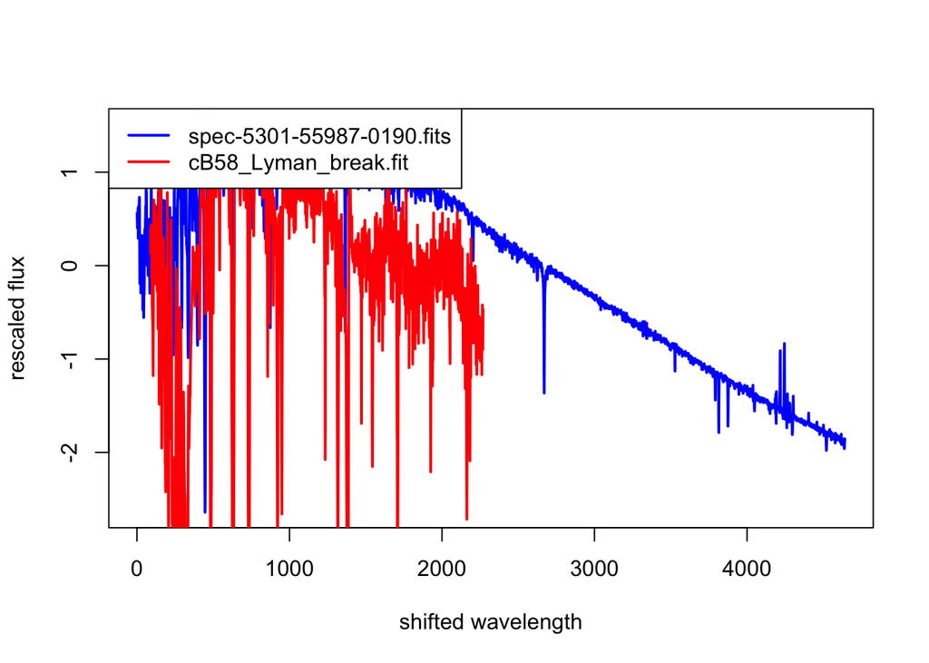

```r
subdata=data[1:3,]
real=readFrameFromFITS("cB58_Lyman_break.fit")$FLUX
zscore <- function(x) {
  return ((x - mean(x)) / sd(x))
}
y2_zscored <- zscore(real)
for(j in 1:3){
  subsubdata=subdata[j,]
  file=subsubdata$filename
  shift=subsubdata$i
  cat(sep="", "file=", file, "\n")
  path_to_file = paste(sep="", "data/", file)
  cat(sep="", "path_to_file=", path_to_file, "\n")
  noisy = readFrameFromFITS(path_to_file)$flux # don't save the data frames
  y1_zscored <- zscore(noisy)
  index1=1:length(noisy)
  index2=(1:length(real))+shift
  plot(index1, y1_zscored, type="l", col="blue", lwd=2, ylab="rescaled flux", xlab="shifted wavelength")
  lines(index2, y2_zscored, col="red", lwd=2)
  legend("topleft", legend=c(file, "cB58_Lyman_break.fit"), col=c("blue", "red"), lwd=2)
}
```